# Effect for Those Who Have Received Vaccination Coupon in FY2019

Preview

Hiroki Kato

2022-03-12

## 2019年度ワクチンクーポン券配布対象者に限定したナッジ・メッセージの効果

始めに、2019年度にクーポン券が送付された40歳以上46歳以下の男性グループにおける、 ナッジ・メッセージの意向と行動に対する効果を推定する。

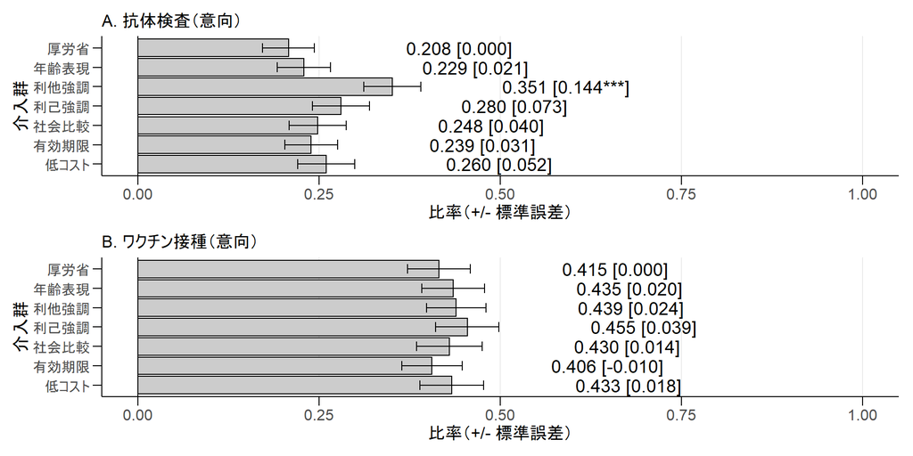

Figure 1: 2019年度クーポン券配布対象者に限定した意向に対するナッジ・メッセージの効果。データソース：Wave 1セレクションデータ。注）図中の数値は各群の比率を示し、角括弧内の数値はナッジ・メッセージの効果の規模（厚労省メッセージ群との差）を示している。効果の統計的な有意性は次の規則に従う：* p < 0.1、** p < 0.05、*** p < 0.01。

図1は各介入群の抗体検査受検とワクチン接種の意向を示している。 結果として、利他強調メッセージは厚労省メッセージよりも抗体検査受検の意向を高めている。 厚労省メッセージを読んだ人の約20.8%が抗体検査を受けたいと回答している一方で、 利他強調メッセージを読んだ人の約35.1%が抗体検査を受けたいと回答している。 したがって、 利他強調メッセージはコントロールよりも約14.3%ポイント抗体検査の受検意向を引き上げており、 これはt検定より統計的に1%水準で有意である。 その他のナッジ・メッセージについては、抗体検査を受けたいと答えた人の割合は30%を下回っていて、 その比率が厚労省メッセージと変わらないという帰無仮説を棄却できない。

また、すべての介入群のワクチン接種の意向の比率は40%から45%の範囲にある。 ワクチン接種の意向の比率が抗体検査受検の意向の比率よりも高い理由は ワクチン接種の意向を調査するときの質問文によるものである。 我々は抗体を持っていないという条件のもとで接種したいかどうかを質問しているので、 質問文がワクチン接種の必要性を強く刺激した可能性がある。 また、二群間の差のt検定を行った結果、 各ナッジ・メッセージと厚労省メッセージの接種意向の比率の差は統計的に有意でない。

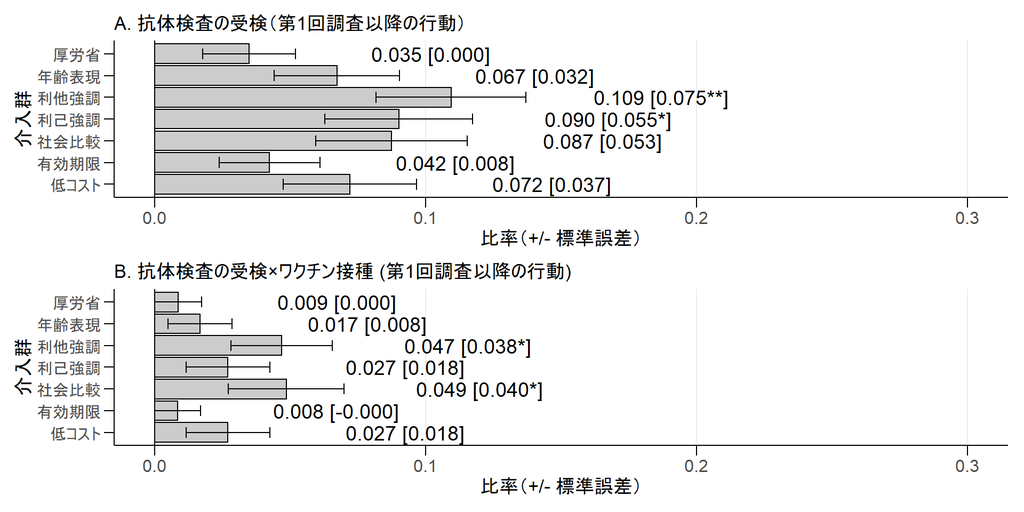

Figure 2: 2019年度クーポン券配布対象者に限定した行動に対するナッジ・メッセージの効果。データソース：Wave 2セレクションデータ。注）図中の数値は各群の比率を示し、角括弧内の数値はナッジ・メッセージの効果の規模（厚労省メッセージ群との差）を示している。効果の統計的な有意性は次の規則に従う：* p < 0.1、** p < 0.05、*** p < 0.01。

図2のパネルAは各介入群の第1回調査以降の抗体検査受検比率を示している。 結果として、利他強調メッセージと利己強調メッセージでは、厚労省メッセージよりも 第1回調査以降の抗体検査の受検比率が高い。 厚労省メッセージを読んだ人の約3.5%は第1回調査以降に抗体検査を受検している。 その一方で、利他強調メッセージを読んだ人の約10.9%と 利己強調メッセージを読んだ人の約9%は第1回調査以降に抗体検査を受検している。 したがって、利他強調メッセージはコントロールに比べて7.4%ポイント抗体検査の受検率を引き上げており、 これはt検定より統計的に5%水準で有意である。 また、利己強調メッセージはコントロールよりも約5.5%ポイント高く、これはt検定より統計的に10%水準で有意である。

図2のパネルBは 各介入群の第1回調査以降の抗体検査とワクチン接種を両方受けた人の比率（以降、ワクチン接種率と呼ぶ）を示している。 この比率は今回の厚生労働省の政策によって新たに抗体を獲得した人の比率を示すので、 政策効果のアウトカム指標となる。 その結果、利他強調メッセージと社会比較メッセージがワクチン接種を促進していることがわかる。 厚労省メッセージを読んだ人の約0.9%が抗体検査を受検し、ワクチンを接種している。 その一方で、利他強調メッセージを読んだ人の約4.7%と 社会比較メッセージを読んだ人の約4.9%が第1回調査以降に抗体検査を受検し、ワクチンを接種している。 よって、利他強調メッセージは3.8%ポイントコントロールよりも高く、これはt検定より統計的に10%水準で有意である。 社会比較メッセージは4%ポイントコントロールよりも高く、これはt検定より統計的に10%水準で有意である。

Table 1: 2019年度クーポン券配布対象者に限定した 抗体検査とワクチン接種の線形確率モデルの推定結果

意向

第1回調査以降の行動

抗体検査

ワクチン接種

抗体検査

抗体検査×ワクチン接種

年齢表現

0.021

0.013

0.020

0.006

0.032

0.030

0.008

0.007

(0.051)

(0.051)

(0.061)

(0.061)

(0.029)

(0.028)

(0.015)

(0.015)

利他強調

0.144***

0.151***

0.024

0.022

0.075**

0.073**

0.038*

0.037*

(0.053)

(0.052)

(0.059)

(0.059)

(0.032)

(0.032)

(0.021)

(0.021)

利己強調

0.073

0.091*

0.039

0.048

0.055*

0.067**

0.018

0.022

(0.053)

(0.052)

(0.061)

(0.061)

(0.032)

(0.032)

(0.018)

(0.018)

社会比較

0.040

0.079

0.014

0.021

0.053

0.065**

0.040*

0.045*

(0.053)

(0.052)

(0.062)

(0.061)

(0.033)

(0.033)

(0.023)

(0.023)

有効期限

0.031

0.026

－0.010

－0.021

0.008

0.008

0.000

0.001

(0.051)

(0.050)

(0.060)

(0.060)

(0.025)

(0.025)

(0.012)

(0.012)

低コスト

0.052

0.053

0.018

0.014

0.037

0.041

0.018

0.022

(0.053)

(0.051)

(0.062)

(0.061)

(0.030)

(0.029)

(0.018)

(0.018)

Num.Obs.

927

881

927

881

805

805

805

805

R2

0.010

0.140

0.001

0.117

0.009

0.037

0.009

0.036

R2 Adj.

0.004

0.120

－0.006

0.097

0.002

0.012

0.002

0.011

共変量

X

X

X

X

Table 2: 利他強調メッセージと比較した介入群の効果 (2019年度クーポン券配布対象者)

意向

第1回調査以降の行動

抗体検査

ワクチン接種

抗体検査

抗体検査×ワクチン接種

厚労省

－0.144***

－0.151***

－0.024

－0.022

－0.075**

－0.073**

－0.038*

－0.037*

(0.053)

(0.052)

(0.059)

(0.059)

(0.032)

(0.032)

(0.021)

(0.021)

年齢表現

－0.122**

－0.138***

－0.004

－0.016

－0.042

－0.043

－0.030

－0.029

(0.054)

(0.052)

(0.060)

(0.058)

(0.036)

(0.036)

(0.022)

(0.022)

利己強調

－0.071

－0.061

0.015

0.026

－0.019

－0.006

－0.020

－0.014

(0.055)

(0.054)

(0.060)

(0.058)

(0.039)

(0.038)

(0.024)

(0.023)

社会比較

－0.103*

－0.072

－0.009

－0.001

－0.022

－0.008

0.002

0.008

(0.056)

(0.054)

(0.061)

(0.058)

(0.039)

(0.039)

(0.028)

(0.028)

有効期限

－0.112**

－0.125**

－0.033

－0.043

－0.067**

－0.066**

－0.038*

－0.036*

(0.053)

(0.052)

(0.058)

(0.058)

(0.033)

(0.033)

(0.021)

(0.021)

低コスト

－0.092*

－0.098*

－0.006

－0.008

－0.037

－0.032

－0.020

－0.014

(0.055)

(0.052)

(0.060)

(0.058)

(0.037)

(0.036)

(0.024)

(0.024)

Num.Obs.

927

881

927

881

805

805

805

805

R2

0.010

0.140

0.001

0.117

0.009

0.037

0.009

0.036

R2 Adj.

0.004

0.120

－0.006

0.097

0.002

0.012

0.002

0.011

共変量

X

X

X

X

Table 3: 2019年度クーポン券配布対象の抗体検査受検者の動き

| ナッジ・メッセージ | サンプルサイズ | 抗体検査の受検 人数 | 抗体検査の受検 二群比較のp値 | 抗体検査の結果が陰性 人数 | 抗体検査の結果が陰性 二群比較のp値 | 陰性かつワクチンを接種 人数 | 陰性かつワクチンを接種 二群比較のp値 |
| --- | --- | --- | --- | --- | --- | --- | --- |
| 厚労省 | 115 | 4 | － | 1 | － | 1 | － |
| 年齢表現 | 119 | 8 | 0.376 | 2 | 1.000 | 2 | 1.000 |
| 利他強調 | 128 | 14 | 0.029 | 7 | 0.588 | 6 | 1.000 |
| 利己強調 | 111 | 10 | 0.102 | 3 | 1.000 | 3 | 1.000 |
| 社会比較 | 103 | 9 | 0.151 | 5 | 0.559 | 5 | 1.000 |
| 有効期限 | 118 | 5 | 1.000 | 1 | 1.000 | 1 | 1.000 |
| 低コスト | 111 | 8 | 0.247 | 5 | 0.545 | 3 | 1.000 |

注）二群比較は、厚労省メッセージ群とあるナッジ・メッセージの二群をFisherの正確検定で分析している。抗体検査の受検をアウトカムとするとき、抗体検査の受検者数に群間で差がないという帰無仮説を検定している。抗体検査の陰性者をアウトカムとするとき、抗体検査の受検者の中で陰性者の比率に群間で差がないという帰無仮説を検定している。陰性者のワクチン接種をアウトカムとするとき、陰性者の中でワクチン接種の比率に群間で差がないという帰無仮説を検定している。

利他強調メッセージと社会比較メッセージがワクチン接種を促進した理由は、 厚労省メッセージ群よりも抗体検査の陰性比率が高いことにある。 この点を明らかにするために、 表3に各群の抗体検査受検者の動きを示した。 この表から二つの発見がある。 第一に、利他強調メッセージと低コストメッセージを除くすべての群で、 抗体検査の結果が陰性である人が全員ワクチンを接種している。 たとえば、厚労省メッセージ群では、1人の陰性者がワクチン接種をしているので、 陰性者のワクチン接種比率は100%である。 ワクチン接種を促進した利他強調メッセージと社会比較メッセージの 陰性者のワクチン接種比率はそれぞれ 86%（$=6/7$）と100%（$=5/5$）である。

第二に、各群の抗体検査の陰性比率は20%から62.5%の範囲にある。 たとえば、厚労省メッセージ群では、4人の抗体検査受検者のうち、 1人が陰性であったので、陰性比率は約25%である。 ワクチン接種を促進した利他強調メッセージと社会強調メッセージの陰性比率はそれぞれ 50%（$=7/14$）と56%（$=5/9$）である。 したがって、厚労省メッセージと比較して、 利他強調メッセージと社会強調メッセージはワクチンを接種するべき人が多くいたので、 これらのメッセージがワクチン接種に対して正の効果があった。 また、利他強調メッセージ群の陰性者のワクチン接種率が100%を下回っているので、 ワクチン接種に対する社会比較メッセージの効果の規模（4%ポイント）が 利他強調メッセージ（3.8%ポイント）より若干大きくなった。

ただし、利他強調メッセージと社会比較メッセージの抗体検査の陰性比率が 厚労省メッセージより高いという発見は偶然である可能性が高い。 我々はあるナッジ・メッセージ群と厚労省メッセージ群の抗体検査受検者に限定して、 陰性者の数が群間で異ならないという帰無仮説を フィッシャーの正確検定で検証し、 そのp値を表3の第6列に示した。 すべてのナッジ・メッセージ群において、 陰性者の数が厚労省のそれと異ならないという帰無仮説を棄却できなかった。 よって、我々のデータでは陰性比率が各群で異なっているが、 母集団では陰性比率は群間で差がない[^1]。

また、介入に関わらず抗体検査の結果が陰性である人のほとんどがワクチンを接種しているという事実は、 抗体検査の受検率を高めることが政策的に重要であることを示唆している。 抗体保有率を高めるための政策介入は二種類が考えられる。 第一に、単純に抗体検査の受検者を増やす政策である。 第二に、抗体検査の結果が陰性である人がワクチンを接種することを促進する政策である。 今回のランダム化比較試験は後者の介入をしていないにも関わらず、 ほとんどの陰性者がワクチンを接種している[^2]。 これは陰性者のワクチン接種を促進する政策よりも抗体検査の受検を促進する政策の方が 効率的に抗体保有率を高められることを示唆している。 このとき、抗体を保有していない人に抗体検査を受検させるような政策を用いることで、 より政策目標を達成できる[^3]。